# A4: Incarceration

### Introduction

The incarceration rate in the state of Washington has changed drastically within the past few decades. In this analysis, we will be focusing on Washington state and our very own King county and examining how rates of imprisonment have changed since the 1990’s. We will be looking at incarceration rates of each race and analyzing them. Furthermore, we will be examining possible distinctions and disparities that could have occurred within our judicial system. Our data set includes data spanning from the years 1990 to 2018.

### Summary Information

The average total prison Population rate is 371.83 across all counties in Washington. It ranges from the lowest being 39.93 and the highest 1173.30. The county with the lowest prisoners is San Juan County, while the county with the most prisoners being Franklin County. There is not an obvious trend in the amount of prisoners within the state of Washington, every county has their own trend. On the other hand, if we look at King County specifically there has been a decrease in prisoners over the last two decades, especially for black and latin people.

### The Dataset

This dataset was collected by the U.S. Department of Justice Bureau of justice Statistics. Which then was compiled by multiple organizations, including the NCRP, NPS, and the DCRP.The data was collected using annual surveys conducted by the jails and prisons. This dataset consists of 1131 observations(rows) and 23 features(columns). Working with this data, we have to consider several ethical questions related to power. We cannot ensure that prisons are ethically collecting this data form the inmates. As stated in our constitution, incarcerated people don’t have the same rights as we do, so we can’t ensure that the methods used to obtain this data is favorable or fair to the inmates.

### Trends Over Time Chart

```
## data frame with 0 columns and 1 row
```

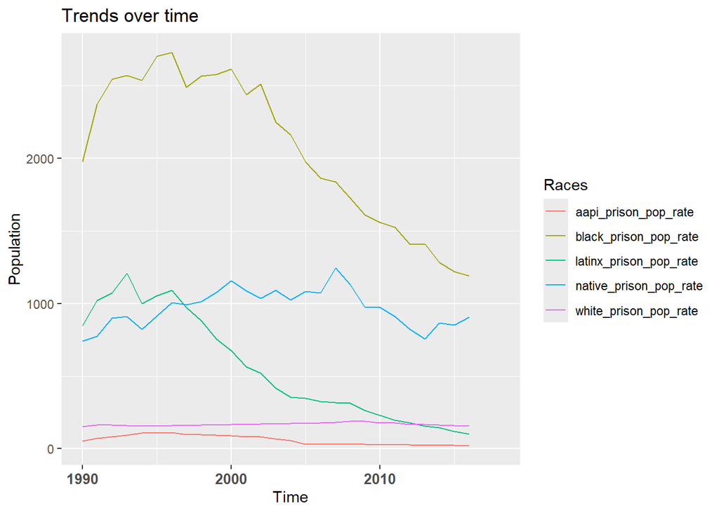

I chose to include this chart in order to find trends in the number of prisoner’s in King County. My graph includes lines for different races, to illustrate and find any differences and commonalities. The graph shows a decrease in prison population rates over the last two decades decades, the groups with biggest decrease being Black and Latin people.

### Variable Comparison Chart

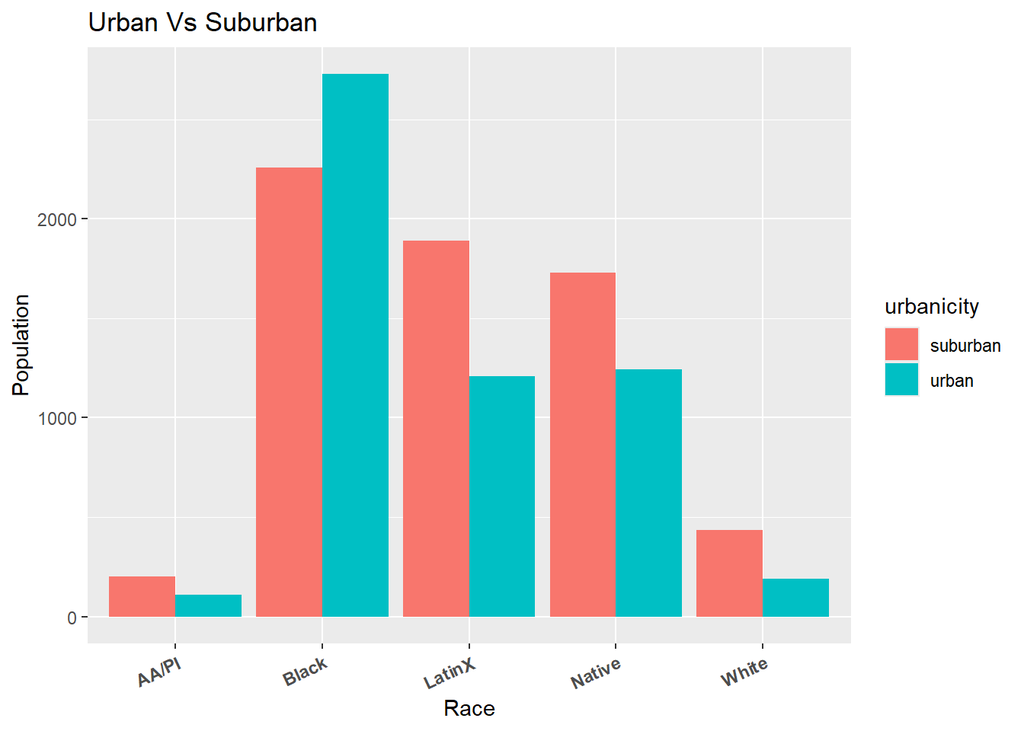

### Map

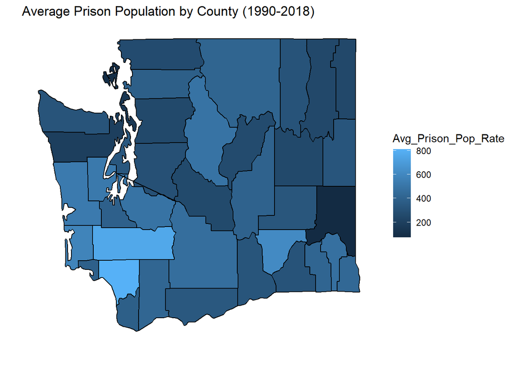

This map illustrates the average prison population of each county in Washington state from 1990 to 2018. The results show that counties in the south west have greater rates of incarceration than in areas like east and north west.